# CustomerLens-Analytics

La Estrategia Multicanal: ¿Más Canales = Más Compras?

Pablo Oliva Muñoz

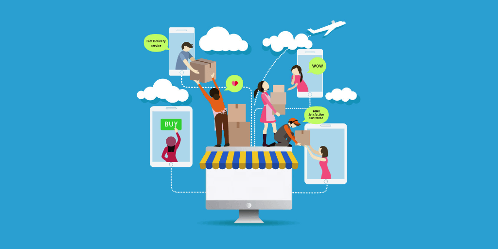

## 1 Introducción

En el comercio que estamos estudiando, la empresa despliega múltiples puntos de contacto con el cliente: la **tienda física**, la **web** y el **catálogo**. Esta estrategia multicanal responde a la intuición de que cuanto más fácil sea comprar, más comprará el cliente. Pero, ¿es esto realmente así? ¿O el efecto se diluye porque los clientes simplemente redistribuyen sus compras entre canales sin aumentar el volumen total?

Esta primera pregunta individual aborda precisamente esa cuestión:

> **¿Aumenta el volumen de compras cuantos más canales utiliza el cliente?**

Responder a esta pregunta tiene implicaciones directas en estrategia comercial: si los clientes multicanal compran más en términos absolutos, la empresa tiene un incentivo claro para incentivar la adopción de múltiples canales. Si no, quizás la inversión en omnicalidad no se justifica por volumen de compra.

En este primer análisis, abordamos la cuestión desde un enfoque exploratorio y descriptivo, utilizando diversas herramientas de visualización para perfilar nuestra base de clientes y cuantificar las diferencias de comportamiento (frecuencia y ticket medio) entre los diferentes segmentos de adopción multicanal.

### Objetivos

1. Describir la **distribución de clientes** según su perfil multicanal.
2. Identificar la estructura del **gasto total** en la base de clientes y los perfiles de valor existentes.
3. Analizar la **intensidad de compra** (volumen y gasto) por perfil multicanal.
4. Determinar si los canales adicionales **incrementan** o sustituyen compras existentes.
5. Evaluar si el efecto multicanal persiste al **controlar por ingresos**.

## 2 Preparación del Entorno y los Datos

```r
library(dplyr)
library(readr)
library(ggplot2)
library(tidyr)
library(scales)
library(forcats)
library(ggpubr)
library(ggrepel)
library(plotly)
```

```r
# Cargamos el dataset ya preprocesado
data <- read_csv("./data/marketing_campaign_processed.csv", show_col_types = FALSE)

data$Education <- factor(data$Education,
                         levels = c("Basic", "2n Cycle", "Graduation", "Master", "PhD"),
                         ordered = TRUE)
data$Marital_Status <- factor(data$Marital_Status,
                              levels = c("Single", "Together", "Married", "Divorced", "Widow"))

data <- data %>%
  mutate(
    Income_Band = cut(Income,
                      breaks = c(0, 30000, 50000, 75000, Inf),
                      labels = c("Bajos (<30k)", "Medios (30k-50k)",
                                 "Altos (50k-75k)", "Muy Altos (>75k)"),
                      include.lowest = TRUE)
  )
```

### Construcción de la variable `Num_Channels`

La variable clave de este análisis es `Num_Channels`: cuántos de los tres canales disponibles ha utilizado el cliente de forma **activa** (al menos 1 compra en ese canal). Excluimos los clientes sin ninguna compra registrada.

```r
data <- data %>%
  mutate(
    Canal_Web     = as.integer(NumWebPurchases     > 0),
    Canal_Catalog = as.integer(NumCatalogPurchases > 0),
    Canal_Store   = as.integer(NumStorePurchases   > 0),
    Num_Channels  = Canal_Web + Canal_Catalog + Canal_Store
  ) %>%
  filter(Num_Channels >= 1)

data$Num_Channels_f <- factor(data$Num_Channels, levels = 1:3,
                               labels = c("1 canal\n(Monocanal)",
                                          "2 canales\n(Bicanal)",
                                          "3 canales\n(Tricanal)"))

# Resumen inicial
data %>%
  count(Num_Channels_f) %>%
  mutate(Porcentaje = percent(n / sum(n), accuracy = 0.1)) %>%
  rename(`Perfil` = Num_Channels_f, `Nº Clientes` = n, `% Total` = Porcentaje)
```

```
## # A tibble: 3 × 3
##   Perfil                  `Nº Clientes` `% Total`
##   <fct>                           <int> <chr>
## 1 "1 canal\n(Monocanal)"             37 1.7%
## 2 "2 canales\n(Bicanal)"            543 24.7%
## 3 "3 canales\n(Tricanal)"          1622 73.7%
```

> **Nota metodológica:** La variable `Num_Channels` toma valores de 1 (monocanal) a 3 (tricanal, usa todos los canales disponibles simultáneamente).

## 3 Distribución: ¿Quiénes son nuestros clientes?

**Objetivo 1:** Describir la distribución de clientes según su perfil multicanal.

Antes de analizar el impacto de los canales, entendemos la estructura base: ¿la clientela tiende hacia la monocanalidad o la multicanalidad? Combinamos el gráfico de barras de distribución con el histograma del volumen de compras por perfil.

```r
dist_data <- data %>%
  count(Num_Channels_f) %>%
  mutate(pct = n / sum(n))

p1 <- ggplot(dist_data, aes(x = Num_Channels_f, y = n, fill = Num_Channels_f,
                            text = paste0("Perfil: ", Num_Channels_f,
                                          "<br>Nº clientes: ", n,
                                          "<br>Proporción: ", percent(pct, accuracy = 0.1)))) +
  geom_col(color = "white", width = 0.6, alpha = 0.9) +
  geom_text(aes(label = paste0(n, "\n(", percent(pct, accuracy = 0.1), ")")),
            vjust = -0.3, fontface = "bold", size = 4) +
  scale_fill_manual(values = c("#74C2E1", "#2A9D8F", "#264653")) +
  scale_y_continuous(expand = expansion(mult = c(0, 0.20))) +
  labs(title    = "Distribución por Perfil Multicanal",
       subtitle = "¿Cuántos clientes son mono, bi o tricanal? (interactivo)",
       x = NULL, y = "Nº clientes") +
  theme_minimal(base_size = 12) +
  theme(plot.title = element_text(face = "bold"), legend.position = "none",
        panel.grid.major.x = element_blank())

p2 <- ggplot(data, aes(x = Total_Purchases, fill = Num_Channels_f,
                       text = paste0("Perfil: ", Num_Channels_f,
                                     "<br>Total compras: ", Total_Purchases))) +
  geom_histogram(binwidth = 2, color = "white", alpha = 0.85) +
  facet_wrap(~ Num_Channels_f, ncol = 1, scales = "free_y") +
  scale_fill_manual(values = c("#74C2E1", "#2A9D8F", "#264653")) +
  labs(title    = "Volumen de Compras por Perfil",
       subtitle = "(interactivo)",
       x = "Total de compras", y = "Frecuencia") +
  theme_minimal(base_size = 12) +
  theme(plot.title = element_text(face = "bold"), legend.position = "none",
        strip.text = element_text(face = "bold", size = 9))

ggplotly(p1, tooltip = "text")
```

[interactive chart not shown]

```r
ggplotly(p2, tooltip = "text")
```

[interactive chart not shown]

**Hallazgo clave:** La gran mayoría son **tricanales (≈73%)** — el comportamiento multicanal es la norma, no la excepción. El histograma lo deja claro: los monocanales se concentran por debajo de las 8 compras, mientras que los tricanales son el único perfil capaz de superar las 15–20 compras de forma sistemática.

## 4 El Gasto Total: ¿Dónde está el dinero?

**Objetivo 2:** Identificar la estructura del gasto total en la base de clientes y los perfiles de valor existentes.

Aplicamos el “zoom” estadístico de la escala logarítmica para ver qué tipos de clientes coexisten realmente en la base de datos.

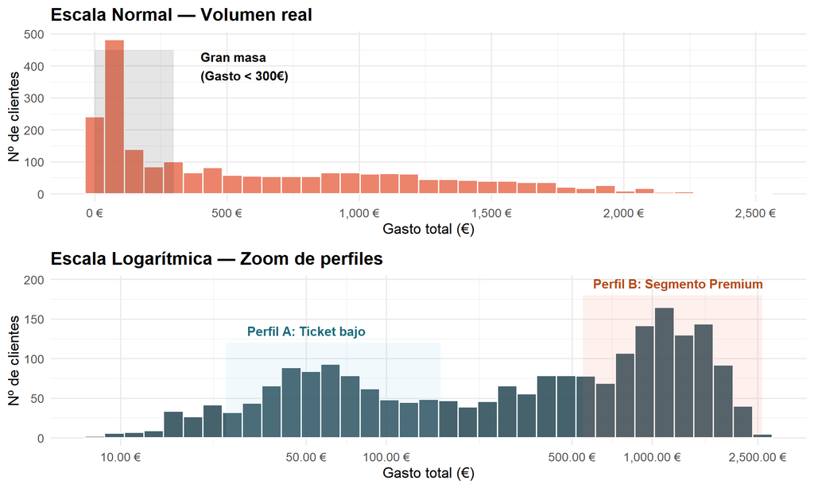

```r
# 1. Gráfico Superior: Escala Normal
hg1 <- ggplot(data, aes(x = Total_Spending)) +
  geom_histogram(bins = 35, fill = "#E76F51", color = "white", alpha = 0.85) +
  annotate("rect", xmin = 0, xmax = 300, ymin = 0, ymax = 450,
           alpha = .1, fill = "black", linetype = "dashed") +
  annotate("text", x = 400, y = 400,
           label = "Gran masa\n(Gasto < 300€)", size = 4, fontface = "bold", hjust = 0) +
  scale_x_continuous(labels = label_dollar(prefix = "", suffix = " €"),
                     breaks = seq(0, 2500, by = 500), # Marcas claras cada 500
                     guide = guide_axis(check.overlap = TRUE)) +
  labs(title = "Escala Normal — Volumen real",
       x = "Gasto total (€)", y = "Nº de clientes") +
  theme_minimal(base_size = 13) +
  theme(plot.title = element_text(face = "bold"))

# 2. Gráfico Inferior: Escala Logarítmica
hg2 <- ggplot(data %>% filter(Total_Spending > 0), aes(x = Total_Spending)) +
  geom_histogram(bins = 35, fill = "#264653", color = "white", alpha = 0.85) +
  # Anotaciones
  annotate("rect", xmin = 25, xmax = 160, ymin = 0, ymax = 120,
           alpha = .1, fill = "#74C2E1", linetype = "dashed") +
  annotate("text", x = 30, y = 135, label = "Perfil A: Ticket bajo",
           size = 4, fontface = "bold", hjust = 0, color = "#1a6b7c") +
  annotate("rect", xmin = 550, xmax = 2600, ymin = 0, ymax = 180,
           alpha = .1, fill = "#E76F51", linetype = "dashed") +
  annotate("text", x = 600, y = 195, label = "Perfil B: Segmento Premium",
           size = 4, fontface = "bold", hjust = 0, color = "#b34c1a") +
  # EJE X MEJORADO
  scale_x_log10(
    breaks = c(10, 50, 100, 500, 1000, 2500),
    labels = label_dollar(prefix = "", suffix = " €")
  ) +
  labs(title = "Escala Logarítmica — Zoom de perfiles",
       x = "Gasto total (€)", y = "Nº de clientes") +
  theme_minimal(base_size = 13) +
  theme(plot.title = element_text(face = "bold"))

# Combinar verticalmente
ggarrange(hg1, hg2, ncol = 1, nrow = 2)
```

**Hallazgo clave:** Sin la escala logarítmica, el **Perfil B (Premium)** sería casi invisible. En escala log descubrimos que no hay un “cliente promedio”, sino dos motores distintos: el **Perfil A** (masa con ticket de 30–150€) y el **Perfil B** (segmento Premium de 600–2.500€). La siguiente sección confirma a cuál de los dos pertenecen mayoritariamente los tricanales.

## 5 Eficiencia Multicanal: ¿Es Real el Aumento?

**Objetivo 3:** Analizar la intensidad de compra (volumen y gasto) por perfil multicanal.

Analizamos si los tricanales simplemente tienen más compras ocasionales o si representan un cambio estructural en el comportamiento del cliente. Combinamos el **violín** (que muestra la forma real de la distribución, como el histograma pero en vertical) con el **boxplot** del gasto total.

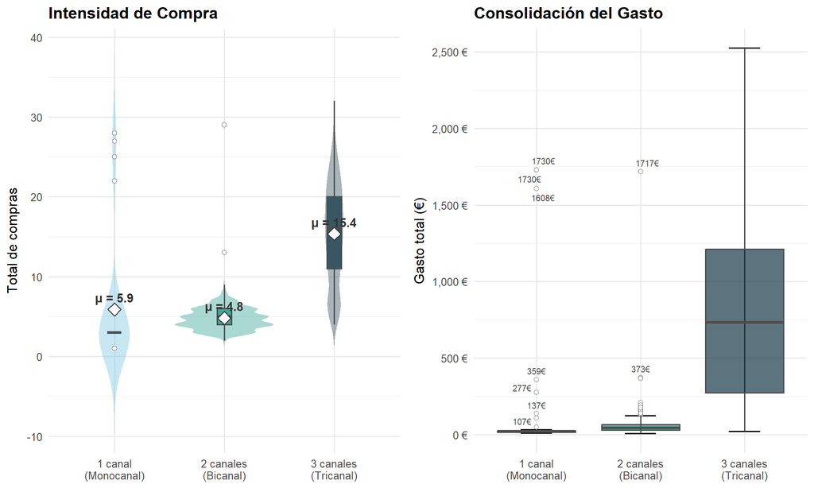

```r
stats_g <- data %>%
  group_by(Num_Channels_f) %>%
  summarise(media = mean(Total_Purchases), .groups = "drop")

p_violin <- ggplot(data, aes(x = Num_Channels_f, y = Total_Purchases, fill = Num_Channels_f)) +
  geom_violin(trim = FALSE, alpha = 0.40, color = NA) +
  geom_boxplot(width = 0.13, outlier.shape = 21, outlier.fill = "white",
               outlier.size = 1.8, color = "gray30", alpha = 0.85) +
  stat_summary(fun = mean, geom = "point", shape = 23, size = 4, fill = "white", color = "gray20") +
  geom_text(data = stats_g,
            aes(x = Num_Channels_f, y = media + 1.5,
                label = paste0("μ = ", round(media, 1))),
            inherit.aes = FALSE, fontface = "bold", size = 3.8, color = "gray20") +
  scale_fill_manual(values = c("#74C2E1", "#2A9D8F", "#264653")) +
  labs(title    = "Intensidad de Compra",
       x = NULL, y = "Total de compras") +
  theme_minimal(base_size = 12) +
  theme(plot.title = element_text(face = "bold"), legend.position = "none")

# Boxplot de gasto con outliers etiquetados
is_outlier <- function(x) {
  x < quantile(x, 0.25) - 1.5 * IQR(x) | x > quantile(x, 0.75) + 1.5 * IQR(x)
}

outlier_data <- data %>%
  group_by(Num_Channels_f) %>%
  mutate(es_outlier = is_outlier(Total_Spending),
         etiq = ifelse(es_outlier, paste0(round(Total_Spending, 0), "€"), "")) %>%
  ungroup()

p_box_gasto <- ggplot(outlier_data,
                       aes(x = Num_Channels_f, y = Total_Spending, fill = Num_Channels_f)) +
  stat_boxplot(geom = "errorbar", width = 0.3) +
  geom_boxplot(outlier.shape = 21, outlier.fill = "white", outlier.size = 1.8,
               alpha = 0.75, color = "gray30") +
  geom_text_repel(aes(label = etiq), size = 2.6, color = "gray30",
                  max.overlaps = 5, segment.color = "gray70") +
  scale_fill_manual(values = c("#74C2E1", "#2A9D8F", "#264653")) +
  scale_y_continuous(labels = dollar_format(prefix = "", suffix = " €")) +
  labs(title    = "Consolidación del Gasto",
       x = NULL, y = "Gasto total (€)") +
  theme_minimal(base_size = 12) +
  theme(plot.title = element_text(face = "bold"), legend.position = "none")

ggarrange(p_violin, p_box_gasto, ncol = 2)
```

## 6 El Mix de Canales: ¿Sustitución o Efecto incremental?

**Objetivo 4:** Determinar si los canales adicionales incrementan o sustituyen compras existentes.

La clave para entender si estamos ante sinergia real o simple redistribución: ¿los tricanales compran más en cada canal individual, o han movido sus compras de un canal a otro?

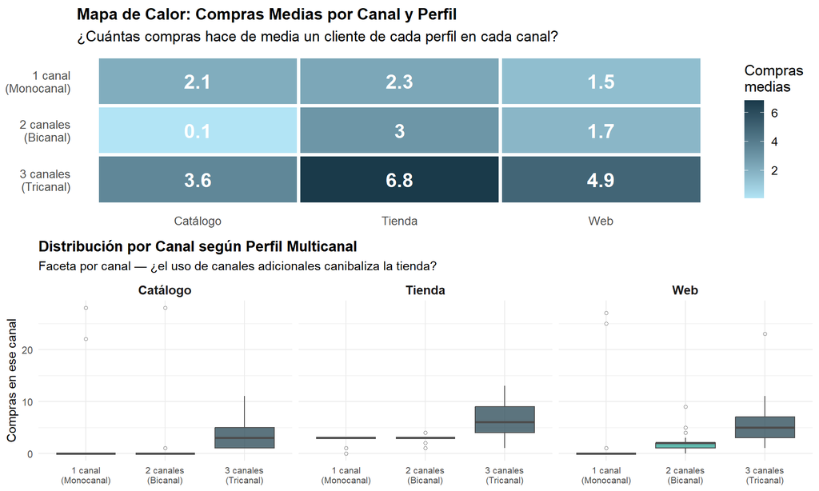

```r
# Heatmap de compras medias por canal y perfil
heat_data <- data %>%
  group_by(Num_Channels_f) %>%
  summarise(Web      = mean(NumWebPurchases),
            Catálogo = mean(NumCatalogPurchases),
            Tienda   = mean(NumStorePurchases),
            .groups  = "drop") %>%
  pivot_longer(cols = -Num_Channels_f, names_to = "Canal", values_to = "Media")

p_heat <- ggplot(heat_data, aes(x = Canal, y = fct_rev(Num_Channels_f), fill = Media)) +
  geom_tile(color = "white", linewidth = 1.5) +
  geom_text(aes(label = round(Media, 1)), fontface = "bold", size = 6, color = "white") +
  scale_fill_gradient(low = "#B2E4F5", high = "#1A3A4A", name = "Compras\nmedias") +
  labs(title    = "Mapa de Calor: Compras Medias por Canal y Perfil",
       subtitle = "¿Cuántas compras hace de media un cliente de cada perfil en cada canal?",
       x = NULL, y = NULL) +
  theme_minimal(base_size = 13) +
  theme(plot.title = element_text(face = "bold", size = 14), panel.grid = element_blank())

# Faceted boxplot por canal: distribución detallada
data_long <- data %>%
  select(Num_Channels_f, NumWebPurchases, NumCatalogPurchases, NumStorePurchases) %>%
  pivot_longer(cols = -Num_Channels_f, names_to = "Canal", values_to = "Compras") %>%
  mutate(Canal = recode(Canal,
                        "NumWebPurchases"     = "Web",
                        "NumCatalogPurchases" = "Catálogo",
                        "NumStorePurchases"   = "Tienda"))

p_facet_canal <- ggplot(data_long, aes(x = Num_Channels_f, y = Compras, fill = Num_Channels_f)) +
  geom_boxplot(outlier.shape = 21, outlier.fill = "white", outlier.size = 1.2,
               alpha = 0.75, color = "gray30") +
  facet_wrap(~ Canal, ncol = 3) +
  scale_fill_manual(values = c("#74C2E1", "#2A9D8F", "#264653")) +
  labs(title    = "Distribución por Canal según Perfil Multicanal",
       subtitle = "Faceta por canal — ¿el uso de canales adicionales canibaliza la tienda?",
       x = NULL, y = "Compras en ese canal") +
  theme_minimal(base_size = 11) +
  theme(plot.title = element_text(face = "bold"), legend.position = "none",
        strip.text = element_text(face = "bold", size = 11),
        axis.text.x = element_text(size = 8))


ggarrange(p_heat, p_facet_canal, nrow = 2, heights = c(1, 1.1))
```

> **Hallazgo clave — No hay efecto sustitución, hay un efecto acumulativo.**

> Esto indica que los clientes multicanal no están trasladando sus compras de la tienda hacia la web o el catálogo, sino que están sumando compras adicionales en los otros canales manteniendo —e incluso aumentando— su actividad en tienda.

## 7 El Factor Ingresos: ¿Es Solo Porque Son Más Ricos?

**Objetivo 5:** Evaluar si el efecto multicanal persiste al controlar por ingresos.

Una hipótesis alternativa plausible es que los clientes tricanales simplemente tienen más dinero, y comprarían más igualmente con independencia del número de canales que usan. Para responder usamos un **gráfico de líneas** que permite visualizar la tendencia del gasto medio al aumentar los canales dentro de cada tramo de ingresos.

```r
line_data <- data %>%
  filter(!is.na(Income_Band)) %>%
  group_by(Income_Band, Num_Channels) %>%
  summarise(Media_Gasto   = mean(Total_Spending),
            Media_Compras = mean(Total_Purchases),
            n             = n(),
            .groups = "drop")

p_linea <- ggplot(line_data, aes(x = Num_Channels, y = Media_Gasto,
                                  color = Income_Band, group = Income_Band,
                                  text = paste0("Ingresos: ", Income_Band,
                                                "<br>Canales: ", Num_Channels,
                                                "<br>Gasto medio: ", dollar(Media_Gasto, prefix = "", suffix = "€", accuracy = 1),
                                                "<br>Nº clientes: ", n))) +
  geom_line(linewidth = 1.3) +
  geom_point(aes(size = n), alpha = 0.9) +
  geom_text(aes(label = dollar(Media_Gasto, prefix = "", suffix = "€", accuracy = 1)),
            vjust = -1.1, size = 3, fontface = "bold", show.legend = FALSE) +
  scale_color_brewer(palette = "Blues", direction = 1, name = "Nivel de\ningresos") +
  scale_size_continuous(name = "Nº clientes", range = c(3, 7), guide = "none") +
  scale_x_continuous(breaks = 1:3, labels = c("Mono\n(1 canal)", "Bi\n(2 canales)", "Tri\n(3 canales)")) +
  scale_y_continuous(labels = dollar_format(prefix = "", suffix = " €"),
                     expand = expansion(mult = c(0.05, 0.15))) +
  labs(
    title    = "Gasto Medio según Ingresos y Número de Canales Activos (interactivo)",
    x        = "Nº de canales activos",
    y        = "Gasto medio (€)",
    caption  = "El tamaño del punto indica el volumen de clientes en ese grupo"
  ) +
  theme_minimal(base_size = 13) +
  theme(plot.title    = element_text(face = "bold", size = 15),
        plot.subtitle = element_text(color = "gray40"),
        plot.caption  = element_text(color = "gray60", face = "italic"),
        legend.position = "right")

ggplotly(p_linea, tooltip = "text")
```

[interactive chart not shown]

> **Hallazgo final:** El efecto multicanal es **robusto en todos los segmentos de renta**.

> El gasto medio aumenta al añadir canales en todos los tramos de renta. Aunque quienes tienen mayores ingresos gastan más en términos absolutos, el incremento asociado al uso de más canales se repite en todos los grupos.

> Por tanto, el efecto multicanal no es solo una cuestión de mayor poder adquisitivo, sino un patrón de compra que se activa al operar en más canales.

## 8 Resumen y Tabla de Métricas Finales

```r
tabla_resumen <- summarise(
  group_by(data, `Perfil multicanal` = Num_Channels_f),
  `Nº clientes`        = n(),
  `% del total`        = percent(n() / nrow(data), accuracy = 0.1),
  `Media compras`      = round(mean(Total_Purchases), 1),
  `Mediana compras`    = round(median(Total_Purchases), 1),
  `Media gasto (€)`    = round(mean(Total_Spending), 0),
  `Mediana gasto (€)`  = round(median(Total_Spending), 0),
  `Media ingresos (€)` = round(mean(Income, na.rm = TRUE), 0),
  .groups              = "drop"
)

tabla_resumen
```

```
## # A tibble: 3 × 8
##   `Perfil multicanal`     `Nº clientes` `% del total` `Media compras`
##   <fct>                           <int> <chr>                   <dbl>
## 1 "1 canal\n(Monocanal)"             37 1.7%                      5.9
## 2 "2 canales\n(Bicanal)"            543 24.7%                     4.8
## 3 "3 canales\n(Tricanal)"          1622 73.7%                    15.4
## # ℹ 4 more variables: `Mediana compras` <dbl>, `Media gasto (€)` <dbl>,
## #   `Mediana gasto (€)` <dbl>, `Media ingresos (€)` <dbl>
```

## 9 Conclusiones

### Síntesis por objetivos

| Objetivo | Resultado |
| --- | --- |
| 1. Perfil multicanal de la clientela | **≈73% son tricanales** — la multicanalidad es la norma, no la excepción |
| 2. Estructura del gasto total | Dos perfiles coexisten: **Perfil A** (masa, ticket bajo) y **Perfil B** (Premium, 600–2.500€) |
| 3. ¿Es real el aumento de gasto? | **Sí** — mediana e IQR crecen sistemáticamente de Mono a Tricanal |
| 4. ¿Sustitución o adición de canales? | **Incrementa**l — los tricanales compran más en **cada canal** por separado (heatmap) |
| 5. ¿Es solo por ingresos? | **No** — el patrón se mantiene en todos los tramos de renta; los ingresos influyen en el nivel de gasto, pero el canal opera por encima de esa influencia |

### Implicaciones para el negocio

**1. La multicanalidad es el comportamiento mayoritario, no marginal**

Con un 73% de clientes tricanales, el diseño de la experiencia de cliente debe tomar la multicanalidad como punto de partida, no como caso especial.

**2. Los dos perfiles de valor requieren estrategias diferenciadas**

El Perfil A (masa) y el Perfil B (Premium) coexisten y ambos se potencian con la multicanalidad. Una estrategia única no captura el valor potencial de ninguno de los dos.

**3. Activar canales adicionales no canibaliza: suma**

> **Siguiente paso estratégico:** Dado que la adopción de canales adicionales correlaciona fuertemente con un mayor gasto, el siguiente reto es diseñar incentivos cruzados (ofertas web-to-store, catálogos interactivos) para empujar a los monocanales/bicanales hacia la fidelización multicanal.

## 10 Referencias

- Harvard Business Review. “A Study of 46,000 Shoppers Shows That Omnichannel Retailing Works”. Recuperado de: https://hbr.org/2017/01/a-study-of-46000-shoppers-shows-that-omnichannel-retailing-works
- InboundCycle. “Qué es el marketing omnicanal, cómo aplicarlo y mucho más”. Recuperado de: https://www.inboundcycle.com/blog-de-inbound-marketing/que-es-el-marketing-omnicanal-como-aplicarlo-y-mucho-mas
- IEBS Business School. “Estrategia Omnicanal en eCommerce: qué es y cómo aplicarla”. Recuperado de: https://www.iebschool.com/hub/estrategia-omnicanal-e-commerce/